# Deep learning in Time Series

## 1 Introduction

in this section, I will use the same uni-variate time-series data that was used in the previous models (ARIMA), the market-breadth measurement of the SPX since 2020-04-07. Thus we can have a better understanding of the effectiveness of deep learning in this kind of time-series data. As something that was known for it’s accuacry, I’m wondering does the deep learning model we testing out today, connected dense model, drop-out regularized GRU and bidirectional LSTM (RNN, GRU, and LSTM) will outperform the model that especially used in time-series analysis like the ARIMA and VAR models in the previous sections.

## 2 Data preparation

### 2.1 Load the data and packages

```python
from matplotlib import pyplot as plt
import numpy as np
import pandas as pd
import tensorflow as tf
from tensorflow.keras.models import Sequential
from tensorflow.keras import layers
from tensorflow.keras.optimizers import RMSprop
from tensorflow.keras.preprocessing import sequence
from sklearn.metrics import mean_squared_error
import math
```

```python
# Read in the data from the csv file
data = pd.read_csv('spy_breadth.csv')

# Select the 'Date' and 'Breadth' columns
data = data[['Date', 'Breadth']]

# Convert the 'Date' column to datetime format
data['Date'] = pd.to_datetime(data['Date'])

# Set the 'Date' column as the index
data.set_index('Date', inplace=True)
```

### 2.2 Data parsing and normalization

```python
mean = data['Breadth'].mean()
data['Breadth'] -= mean
std = data['Breadth'].std()
data['Breadth'] /= std

# Convert the DataFrame to a NumPy array
float_data = data['Breadth'].values.reshape(-1, 1)
```

After loading the market breadth data, the array has been prasing and normalized for a better calculation efficiency in the later stages.

## 3 Model preparation

### 3.1 Generator yileding timeseries samples and their targets

```python
def generator(data, lookback, delay, min_index, max_index,
              shuffle=False, batch_size=128, step=6):

    # data —The original array of floating-point data (normalized)
    # lookback - How many timesteps back the input data should go
    # delay - How many timesteps in the future the target should be.
    # min_index and max_index - Indices in the data array that delimite which timestep to draw from. This is useful for keeping a segemtn of the data for validation and another for testing.
    # shuffle - Whether to shuffle the samples ot draw them in chronological order.
    # batch_size - The number of samples per batch
    # step - The period, in timsteps, at which you sample data. You'll set it to 6 in order to draw one daya point every hour

    if max_index is None:
        max_index = len(data) - delay - 1
    i = min_index + lookback
    # print("HERE")
    while 1:
        if shuffle:
            rows = np.random.randint(
                min_index + lookback, max_index, size=batch_size)
            # print(rows); exit()
        else:
            if i + batch_size >= max_index:
                i = min_index + lookback
            rows = np.arange(i, min(i + batch_size, max_index))
            i += len(rows)

        #print(rows); # exit()
        samples = np.zeros((len(rows),
                           lookback // step,
                           data.shape[-1]))
        targets = np.zeros((len(rows),))

        for j, row in enumerate(rows):
            indices = range(rows[j] - lookback, rows[j], step)
            samples[j] = data[indices]
            targets[j] = data[rows[j] + delay][0]
        #@print("here"); # exit()

        yield samples, targets
```

```python
def generator(data, lookback, delay, min_index, max_index,
              shuffle=False, batch_size=128, step=6, stop_at_max_index=False):

    if max_index is None:
        max_index = len(data) - delay - 1
    i = min_index + lookback

    while 1:
        if shuffle:
            rows = np.random.randint(
                min_index + lookback, max_index, size=batch_size)
        else:
            if i + batch_size >= max_index:
                if stop_at_max_index:
                    break
                i = min_index + lookback
            rows = np.arange(i, min(i + batch_size, max_index))
            i += len(rows)

        samples = np.zeros((len(rows),
                            lookback // step,
                            data.shape[-1]))
        targets = np.zeros((len(rows),))

        for j, row in enumerate(rows):
            indices = range(rows[j] - lookback, rows[j], step)
            samples[j] = data[indices]
            targets[j] = data[rows[j] + delay][0]

        yield samples, targets
```

### 3.2 Preparing the training, validation , and test generators

To avoid possible over fitting, I have split the dataset into train/validation data-sets and testing for the final model comparision. I will also use regularization like drop-outs on GRU to avoid over-fitting.

```python
# Change lookback, delay, batch_size, and step to smaller values
lookback = 30
step = 1
delay = 5
batch_size = 32

# Calculate the indices for train/validation/test data
train_val_split = int(0.6 * len(float_data))  # 60% of the data for training
val_test_split = int(0.8 * len(float_data))   # 20% of the data for validation, 20% for testing

# Calculate the validation and test steps
val_steps = (val_test_split - train_val_split - lookback)
test_steps = (len(float_data) - val_test_split - lookback) // batch_size

# Update the indices in the generator functions
train_gen = generator(float_data,
                      lookback=lookback,
                      delay=delay,
                      min_index=0,
                      max_index=train_val_split,
                      shuffle=True,
                      step=step,
                      batch_size=batch_size)

val_gen = generator(float_data,
                    lookback=lookback,
                    delay=delay,
                    min_index=train_val_split,
                    max_index=val_test_split,
                    step=step,
                    batch_size=batch_size)

def test_gen_func():
    return generator(float_data,
                     lookback=lookback,
                     delay=delay,
                     min_index=val_test_split,
                     max_index=None,
                     step=step,
                     batch_size=batch_size,
                     stop_at_max_index=True)
```

## 4 Deep Learning Modeling

1. Dense Connected Model: In the context of deep learning, a dense connected model often refers to a network consisting of multiple fully connected layers (also called dense layers). These layers are composed of neurons with learned weights and biases, which are adjusted during training to minimize a loss function. However, they can be computationally expensive and prone to overfitting, especially when dealing with large datasets or high-dimensional input features.
2. Dropout-regularized GRU: The drop out means that some neurons are not updated in each training iteration, forcing the model to learn more robust and generalizable features., dropout regularization helps prevent overfitting by randomly dropping out neurons during training. It can be applied to GRUs and other RNN types.
3. Bidirectional LSTM: A bidirectional LSTM combines the benefits of LSTMs and bidirectional RNNs. It consists of two separate LSTMs, one processing the input sequence in the forward direction and the other processing it in the reverse direction. The outputs from both LSTMs are then combined. This allows the model to capture both past and future context, potentially improving performance.

### 4.1 Dense connnected model

```python
# Enable mixed precision training for speedup on NVIDIA GPUs
from tensorflow.keras import mixed_precision
mixed_precision.set_global_policy('mixed_float16')

# Dense connected model
dense_model = Sequential()
dense_model.add(layers.Flatten(input_shape=(lookback // step, float_data.shape[-1])))
dense_model.add(layers.Dense(32, activation='relu'))
dense_model.add(layers.Dense(1, dtype='float32'))
dense_model.add(layers.Activation('linear'))
dense_model.compile(optimizer="RMSprop", loss='mae')

dense_history = dense_model.fit(train_gen,
                                steps_per_epoch=50,
                                epochs=100,
                                validation_data=val_gen,
                                validation_steps=val_steps)
```

```
INFO:tensorflow:Mixed precision compatibility check (mixed_float16): OK
Your GPU will likely run quickly with dtype policy mixed_float16 as it has compute capability of at least 7.0. Your GPU: NVIDIA GeForce RTX 4090, compute capability 8.9
```

### 4.2 Drop-out regularized GRU model

```python
# Drop out regularized GRU
gru_model = Sequential()
gru_model.add(layers.GRU(32,
                         dropout=0.1,
                         recurrent_dropout=0.5,
                         return_sequences=True,
                         input_shape=(None, float_data.shape[-1])))
gru_model.add(layers.GRU(64, activation='relu',
                         dropout=0.1,
                         recurrent_dropout=0.5))
gru_model.add(layers.Dense(1, dtype='float32'))
gru_model.add(layers.Activation('linear'))
gru_model.compile(optimizer=RMSprop(), loss='mae')


# Train for more epochs and use early stopping
from tensorflow.keras.callbacks import EarlyStopping

early_stopping = EarlyStopping(monitor='val_loss', patience=5)

gru_history = gru_model.fit(train_gen,
                            steps_per_epoch=50,
                            epochs=50,
                            validation_data=val_gen,
                            validation_steps=val_steps,
                            callbacks=[early_stopping])
```

```
WARNING:tensorflow:Layer gru will not use cuDNN kernels since it doesn't meet the criteria. It will use a generic GPU kernel as fallback when running on GPU.
```

```
WARNING:tensorflow:Layer gru_1 will not use cuDNN kernels since it doesn't meet the criteria. It will use a generic GPU kernel as fallback when running on GPU.
```

### 4.3 Bidirectional LSTM

```python
lstm_model = Sequential()
lstm_model.add(layers.Bidirectional(layers.LSTM(32), input_shape=(None, float_data.shape[-1])))
lstm_model.add(layers.Dense(1, dtype='float32'))
lstm_model.add(layers.Activation('linear'))
lstm_model.compile(optimizer='rmsprop', loss='mae')

lstm_history = lstm_model.fit(train_gen,
                              steps_per_epoch=50,
                              epochs=50,
                              validation_data=val_gen,
                              validation_steps=val_steps)
```

### 4.4 Train and Validation Plot- Accuracy comparision

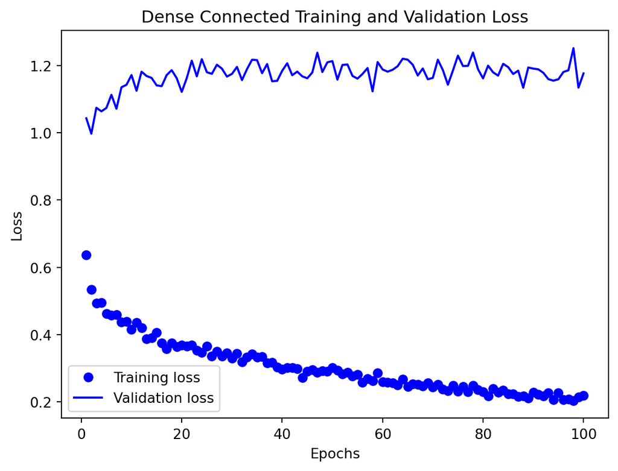

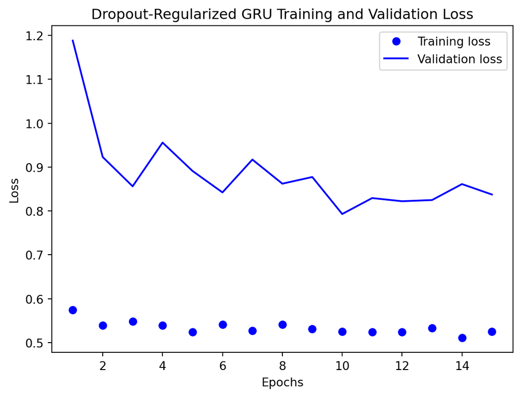

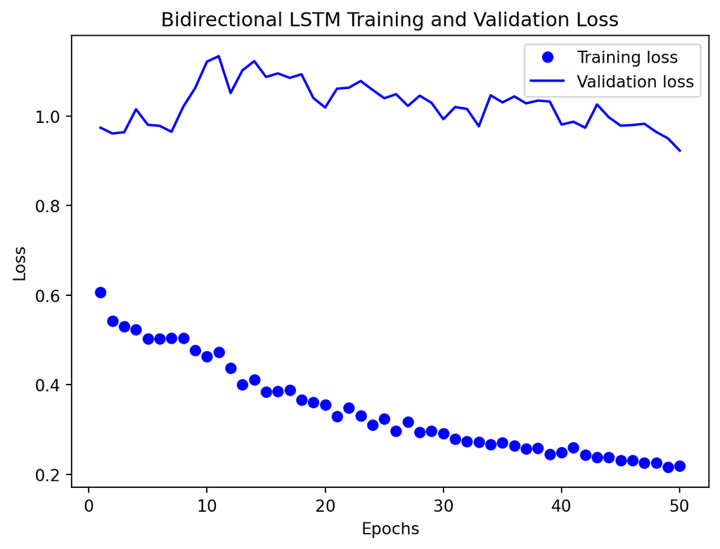

```python
import matplotlib.pyplot as plt

def plot_loss(history, model_name):
    loss = history.history['loss']
    val_loss = history.history['val_loss']
    epochs = range(1, len(loss) + 1)

    plt.plot(epochs, loss, 'bo', label='Training loss')
    plt.plot(epochs, val_loss, 'b', label='Validation loss')
    plt.title(f'{model_name} Training and Validation Loss')
    plt.xlabel('Epochs')
    plt.ylabel('Loss')
    plt.legend()
    plt.show()

# Plot the training and validation loss for each model
plot_loss(dense_history, 'Dense Connected')
plot_loss(gru_history, 'Dropout-Regularized GRU')
plot_loss(lstm_history, 'Bidirectional LSTM')
```

From the train and validation loss plot, it’s clear that all model prone to overfit regarding this time series. However, the drop-out regularized GRU model have a slightly better result compare to the other two model when facing the unseen data.

### 4.5 Regularization effect and future prediction

Regularization definetly help to improve the accuracy and reduce overfitting of the model, since the GRU with drop-out regularized clearly outperform the other two. I have also text some other model in the background without reguarlization like drop-out method and early stopping, the result is not ideal as I hoped for.

As for how far in the future can the deep learning accurately predict the future, I think this question dependes on the time series data been applied to the model. As for the market breadth data, I dont think deep learning can provide a reasonable prediction of the future market breadth data. However, these model might still be useful when predicing other type of data like temperatures.

### 4.6 Model Comparision with previous models (RMSE)

```python
def calculate_rmse(model, test_gen_func, test_steps):
    n_total = 0
    mse_sum = 0
    test_gen = test_gen_func()

    for i in range(test_steps):
        x_test_batch, y_test_batch = next(test_gen)
        y_pred_batch = model.predict(x_test_batch)
        mse_batch = mean_squared_error(y_test_batch, y_pred_batch)
        mse_sum += mse_batch * len(y_test_batch)
        n_total += len(y_test_batch)

    rmse = math.sqrt(mse_sum / n_total)
    return rmse
```

```python
dense_rmse = calculate_rmse(dense_model, test_gen_func, test_steps)
gru_rmse = calculate_rmse(gru_model, test_gen_func, test_steps)
lstm_rmse = calculate_rmse(lstm_model, test_gen_func, test_steps)

# Display RMSE in a table
results = pd.DataFrame({"Model": ["Dense Connected", "Dropout-regularized GRU", "Bidirectional LSTM", "ARIMA modeling", "VAR on Breadth"],
                        "RMSE": [dense_rmse, gru_rmse, lstm_rmse,0.213,0.1107]})
print(results)
```

```
                     Model      RMSE
0          Dense Connected  0.936998
1  Dropout-regularized GRU  0.762341
2       Bidirectional LSTM  0.886125
3           ARIMA modeling  0.213000
4           VAR on Breadth  0.110700
```

### 4.7 Forecast comparision

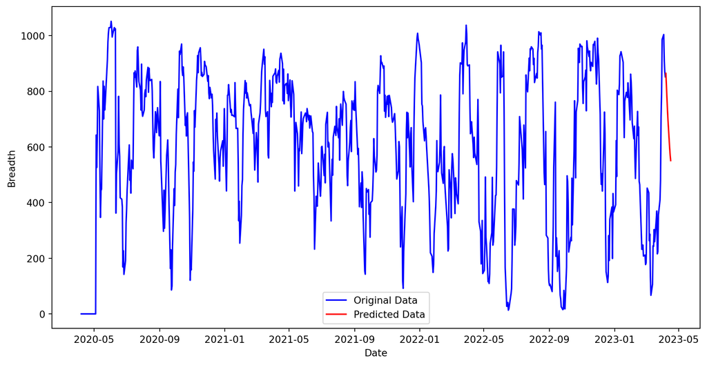

```python
import numpy as np
import pandas as pd
import matplotlib.pyplot as plt

# Get the last lookback days of data (excluding the last row)
last_lookback_data = float_data[-lookback-1:-1]

# Reshape the data into a format suitable for input to the GRU model
input_data = np.reshape(last_lookback_data, (1, lookback, float_data.shape[-1]))

# Predict the next 10 days using the GRU model
next_10_days_predictions = []

for _ in range(10):
    # Make a prediction for the next day
    next_day_prediction = gru_model.predict(input_data)[0, 0]

    # Append the prediction to the list of next 10 days predictions
    next_10_days_predictions.append(next_day_prediction)

    # Update the input data by removing the oldest day and adding the predicted day
    input_data = np.roll(input_data, -1, axis=1)
    input_data[0, -1, 0] = next_day_prediction

# Reverse the normalization for the predicted values
next_10_days_predictions = (np.array(next_10_days_predictions) * std) + mean

# Create a new DataFrame to store the predicted data
predicted_data = pd.DataFrame(next_10_days_predictions, columns=['Breadth'])

# Add 1 day to the last date in the original data for the start date of the predictions
start_date = data.index[-1] + pd.Timedelta(days=1)

# Create a date range for the predicted data
predicted_dates = pd.date_range(start=start_date, periods=10)

# Set the index of the predicted_data DataFrame to the predicted_dates
predicted_data['Date'] = predicted_dates
predicted_data.set_index('Date', inplace=True)

# Combine the original data and the predicted data
combined_data = pd.concat([data, predicted_data])

# Reverse the normalization for the original data
data['Breadth'] = (data['Breadth'] * std) + mean

# Plot the original data and the predictions
plt.figure(figsize=(12, 6))
plt.plot(data.index, data['Breadth'], label='Original Data', color='blue')
plt.plot(predicted_data.index, predicted_data['Breadth'], label='Predicted Data', color='red')
plt.xlabel('Date')
plt.ylabel('Breadth')
plt.legend()
plt.show()
```

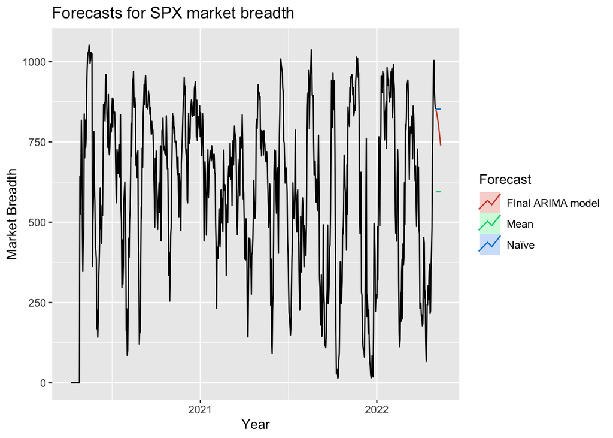

“Forcast for ARIMA models”

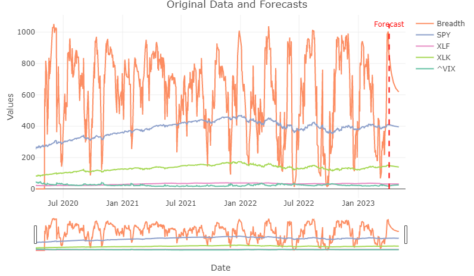

“Forecast for VAR model on market breadth”

In summary, the time series models, ARIMA and VAR, demonstrated better forecasting performance for this particular dataset compared to the deep learning models. This could be due to the inherent ability of time series models to capture linear patterns and seasonality in the data. However, deep learning models, such as the Dropout-regularized GRU, may still provide valuable insights and perform well in certain forecasting scenarios. It is important to consider the nature of the data and the specific problem at hand when selecting the appropriate model for forecasting.

It is evident that the VAR model on Breadth has the lowest RMSE of 0.1107, followed by the ARIMA modeling with an RMSE of 0.213. This suggests that the time series models (ARIMA and VAR) have a better forecasting performance compared to the deep learning models. Although this effect might not be clear on the forecast plot.